# Efectos Heterogéneos (CATE) — Ser Pilo Paga

Movilidad Social y Educación de Élite | Métodos Analíticos · ITAM 2026-I

Avril Salazar · Paulina Garza · Othoniel Reyes

20 de mayo de 2026

## 0. Configuración

```r
library(tidyverse)
library(hrbrthemes)
library(patchwork)
library(scales)
library(knitr)
library(kableExtra)
library(rdrobust)

theme_set(
  theme_ipsum_rc(base_size = 12, plot_title_size = 14, axis_title_size = 11)
)

COL_CTRL <- "#4A6FA5"
COL_TRAT <- "#E07A5F"
COL_UMBR <- "#2D2D2D"

df <- read_csv("../data/spp_microset.csv", show_col_types = FALSE)

# Estimación principal para recuperar h* (referencia para toda la sección)
main_fit  <- rdrobust(y = df$Y, x = df$X1, fuzzy = df$D)
h_main    <- main_fit$bws[1, 1]
late_main <- main_fit$coef[3]
se_main   <- main_fit$se[3]
```

## 1. Estrategia para estimar CATE en Fuzzy RDD

El LATE estimado en `03_fuzzy_rdd.Rmd` es un promedio sobre todos los *compliers* en la vecindad del umbral. El **CATE** (Conditional Average Treatment Effect) desagrega ese efecto por subgrupo para responder: ¿el programa beneficia por igual a mujeres y hombres, a minorías y no-minorías, a estudiantes de estrato bajo y alto?

### Método: partición de muestra por subgrupo

Corremos `rdrobust` de forma **separada** dentro de cada subgrupo. Cada estimación produce el LATE para los *compliers de ese subgrupo* — personas que se inscriben en universidad de élite si y solo si son elegibles y pertenecen a ese grupo.

```r
# Función auxiliar: corre rdrobust dentro de un subconjunto de filas
cate_run <- function(mask, label) {
  df_sub <- df[mask & !is.na(mask), ]
  fit <- tryCatch(
    rdrobust(y = df_sub$Y, x = df_sub$X1, fuzzy = df_sub$D),
    error = function(e) NULL
  )
  if (is.null(fit)) return(NULL)
  h_val <- fit$bws[1, 1]
  tibble(
    Subgrupo   = label,
    n          = nrow(df_sub),
    LATE       = round(fit$coef[3], 4),
    SE         = round(fit$se[3],   4),
    `p-valor`  = round(fit$pv[3],   4),
    `IC inf.`  = round(fit$ci[3,1], 4),
    `IC sup.`  = round(fit$ci[3,2], 4),
    h          = round(h_val, 2),
    `N ef.`    = sum(abs(df_sub$X1) <= h_val, na.rm = TRUE)
  )
}

# Test z para diferencia entre dos CATEs
test_diff <- function(late1, se1, late2, se2, label) {
  z_stat <- (late1 - late2) / sqrt(se1^2 + se2^2)
  p_val  <- 2 * (1 - pnorm(abs(z_stat)))
  tibble(
    Contraste  = label,
    Diferencia = round(late1 - late2, 4),
    `z-stat`   = round(z_stat, 3),
    `p-valor`  = round(p_val, 4),
    Sig.       = case_when(p_val < 0.01 ~ "***",
                           p_val < 0.05 ~ "**",
                           p_val < 0.10 ~ "*",
                           TRUE         ~ "n.s.")
  )
}
```

## 2. Heterogeneidad por género

¿La beca SPP beneficia más a mujeres o a hombres?

```r
cate_genero <- bind_rows(
  cate_run(df$icfes_female == 0, "Hombres"),
  cate_run(df$icfes_female == 1, "Mujeres")
)

cate_genero %>%
  kable(caption = "CATE por género") %>%
  kable_styling(bootstrap_options = c("striped", "hover", "condensed"))
```

CATE por género

| Subgrupo | n | LATE | SE | p-valor | IC inf. | IC sup. | h | N ef. |
| --- | --- | --- | --- | --- | --- | --- | --- | --- |
| Hombres | 13152 | 0.3876 | 0.0488 | 0 | 0.292 | 0.4832 | 12.0 | 5758 |
| Mujeres | 9980 | 0.5142 | 0.0598 | 0 | 0.397 | 0.6314 | 8.5 | 3157 |

```r
test_diff(
  cate_genero$LATE[cate_genero$Subgrupo == "Mujeres"],
  cate_genero$SE[cate_genero$Subgrupo   == "Mujeres"],
  cate_genero$LATE[cate_genero$Subgrupo == "Hombres"],
  cate_genero$SE[cate_genero$Subgrupo   == "Hombres"],
  label = "Mujeres − Hombres"
) %>%
  kable(caption = "Test z: diferencia de LATE entre géneros") %>%
  kable_styling(bootstrap_options = c("striped", "hover"), full_width = FALSE)
```

Test z: diferencia de LATE entre géneros

| Contraste | Diferencia | z-stat | p-valor | Sig. |
| --- | --- | --- | --- | --- |
| Mujeres − Hombres | 0.1266 | 1.64 | 0.101 | n.s. |

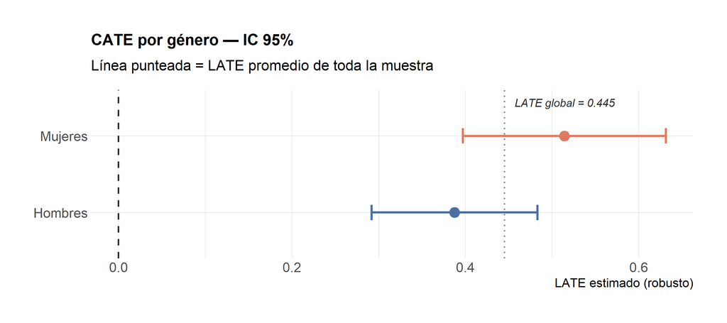

```r
cate_genero %>%
  ggplot(aes(x = LATE, y = Subgrupo, color = Subgrupo)) +
  geom_vline(xintercept = 0,         color = COL_UMBR, linetype = "dashed",  linewidth = 0.7) +
  geom_vline(xintercept = late_main, color = COL_UMBR, linetype = "dotted",  linewidth = 0.6, alpha = 0.6) +
  geom_errorbarh(aes(xmin = `IC inf.`, xmax = `IC sup.`),
                 height = 0.2, linewidth = 0.9) +
  geom_point(size = 4) +
  scale_color_manual(values = c("Hombres" = COL_CTRL, "Mujeres" = COL_TRAT)) +
  annotate("text", x = late_main, y = Inf, vjust = 2, hjust = -0.1,
           size = 3.5, color = COL_UMBR, fontface = "italic",
           label = paste0("LATE global = ", round(late_main, 3))) +
  labs(title = "CATE por género — IC 95%",
       subtitle = "Línea punteada = LATE promedio de toda la muestra",
       x = "LATE estimado (robusto)", y = NULL, color = NULL) +
  theme(legend.position = "none")
```

## 3. Heterogeneidad por minoría subrepresentada (URM)

Las minorías étnicas enfrentan barreras adicionales de acceso a educación superior. ¿La beca SPP cierra esta brecha?

```r
cate_urm <- bind_rows(
  cate_run(df$icfes_urm == 0, "No minoría"),
  cate_run(df$icfes_urm == 1, "Minoría (URM)")
)

cate_urm %>%
  kable(caption = "CATE por estatus de minoría (URM)") %>%
  kable_styling(bootstrap_options = c("striped", "hover", "condensed"))
```

CATE por estatus de minoría (URM)

| Subgrupo | n | LATE | SE | p-valor | IC inf. | IC sup. | h | N ef. |
| --- | --- | --- | --- | --- | --- | --- | --- | --- |
| No minoría | 21575 | 0.4529 | 0.0431 | 0.0000 | 0.3685 | 0.5373 | 8.48 | 6867 |
| Minoría (URM) | 1557 | 0.4020 | 0.1623 | 0.0133 | 0.0838 | 0.7201 | 8.65 | 449 |

```r
test_diff(
  cate_urm$LATE[cate_urm$Subgrupo == "Minoría (URM)"],
  cate_urm$SE[cate_urm$Subgrupo   == "Minoría (URM)"],
  cate_urm$LATE[cate_urm$Subgrupo == "No minoría"],
  cate_urm$SE[cate_urm$Subgrupo   == "No minoría"],
  label = "URM − No minoría"
) %>%
  kable(caption = "Test z: diferencia de LATE entre grupos étnicos") %>%
  kable_styling(bootstrap_options = c("striped", "hover"), full_width = FALSE)
```

Test z: diferencia de LATE entre grupos étnicos

| Contraste | Diferencia | z-stat | p-valor | Sig. |
| --- | --- | --- | --- | --- |
| URM − No minoría | -0.0509 | -0.303 | 0.7618 | n.s. |

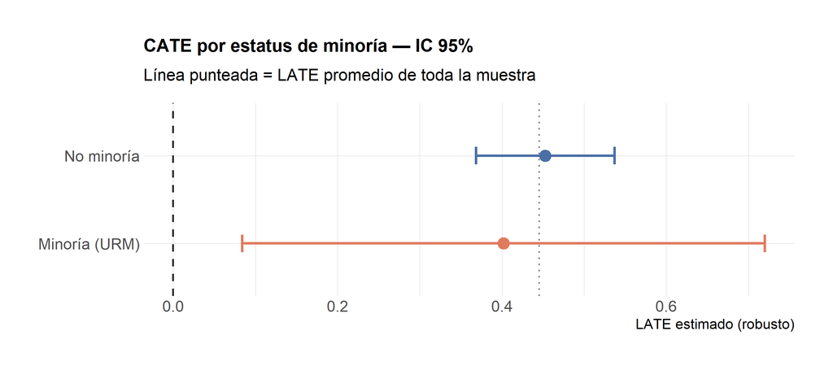

```r
cate_urm %>%
  ggplot(aes(x = LATE, y = Subgrupo, color = Subgrupo)) +
  geom_vline(xintercept = 0,         color = COL_UMBR, linetype = "dashed", linewidth = 0.7) +
  geom_vline(xintercept = late_main, color = COL_UMBR, linetype = "dotted", linewidth = 0.6, alpha = 0.6) +
  geom_errorbarh(aes(xmin = `IC inf.`, xmax = `IC sup.`),
                 height = 0.2, linewidth = 0.9) +
  geom_point(size = 4) +
  scale_color_manual(values = c("No minoría" = COL_CTRL, "Minoría (URM)" = COL_TRAT)) +
  labs(title = "CATE por estatus de minoría — IC 95%",
       subtitle = "Línea punteada = LATE promedio de toda la muestra",
       x = "LATE estimado (robusto)", y = NULL, color = NULL) +
  theme(legend.position = "none")
```

## 4. Heterogeneidad por estrato socioeconómico

Agrupamos en tres categorías para tener suficientes observaciones en cada subgrupo. La mayoría de los estudiantes de SPP se concentra en estratos 1 y 2.

```r
df_str <- df %>% filter(!is.na(icfes_stratum))

cate_estrato <- bind_rows(
  cate_run(!is.na(df$icfes_stratum) & df$icfes_stratum == 1, "Estrato 1"),
  cate_run(!is.na(df$icfes_stratum) & df$icfes_stratum == 2, "Estrato 2"),
  cate_run(!is.na(df$icfes_stratum) & df$icfes_stratum >= 3, "Estrato 3+")
)

cate_estrato %>%
  kable(caption = "CATE por estrato socioeconómico") %>%
  kable_styling(bootstrap_options = c("striped", "hover", "condensed"))
```

CATE por estrato socioeconómico

| Subgrupo | n | LATE | SE | p-valor | IC inf. | IC sup. | h | N ef. |
| --- | --- | --- | --- | --- | --- | --- | --- | --- |
| Estrato 1 | 5265 | 0.4624 | 0.1358 | 7e-04 | 0.1962 | 0.7287 | 8.27 | 1009 |
| Estrato 2 | 10742 | 0.4709 | 0.0485 | 0e+00 | 0.3759 | 0.5659 | 12.15 | 5151 |
| Estrato 3+ | 7066 | 0.4435 | 0.0763 | 0e+00 | 0.2939 | 0.5931 | 6.31 | 1913 |

```r
bind_rows(
  test_diff(
    cate_estrato$LATE[cate_estrato$Subgrupo == "Estrato 1"],
    cate_estrato$SE[cate_estrato$Subgrupo   == "Estrato 1"],
    cate_estrato$LATE[cate_estrato$Subgrupo == "Estrato 2"],
    cate_estrato$SE[cate_estrato$Subgrupo   == "Estrato 2"],
    "Estrato 1 − Estrato 2"
  ),
  test_diff(
    cate_estrato$LATE[cate_estrato$Subgrupo == "Estrato 1"],
    cate_estrato$SE[cate_estrato$Subgrupo   == "Estrato 1"],
    cate_estrato$LATE[cate_estrato$Subgrupo == "Estrato 3+"],
    cate_estrato$SE[cate_estrato$Subgrupo   == "Estrato 3+"],
    "Estrato 1 − Estrato 3+"
  ),
  test_diff(
    cate_estrato$LATE[cate_estrato$Subgrupo == "Estrato 2"],
    cate_estrato$SE[cate_estrato$Subgrupo   == "Estrato 2"],
    cate_estrato$LATE[cate_estrato$Subgrupo == "Estrato 3+"],
    cate_estrato$SE[cate_estrato$Subgrupo   == "Estrato 3+"],
    "Estrato 2 − Estrato 3+"
  )
) %>%
  kable(caption = "Tests z: diferencias de LATE entre estratos") %>%
  kable_styling(bootstrap_options = c("striped", "hover"), full_width = FALSE)
```

Tests z: diferencias de LATE entre estratos

| Contraste | Diferencia | z-stat | p-valor | Sig. |
| --- | --- | --- | --- | --- |
| Estrato 1 − Estrato 2 | -0.0085 | -0.059 | 0.9530 | n.s. |
| Estrato 1 − Estrato 3+ | 0.0189 | 0.121 | 0.9034 | n.s. |
| Estrato 2 − Estrato 3+ | 0.0274 | 0.303 | 0.7618 | n.s. |

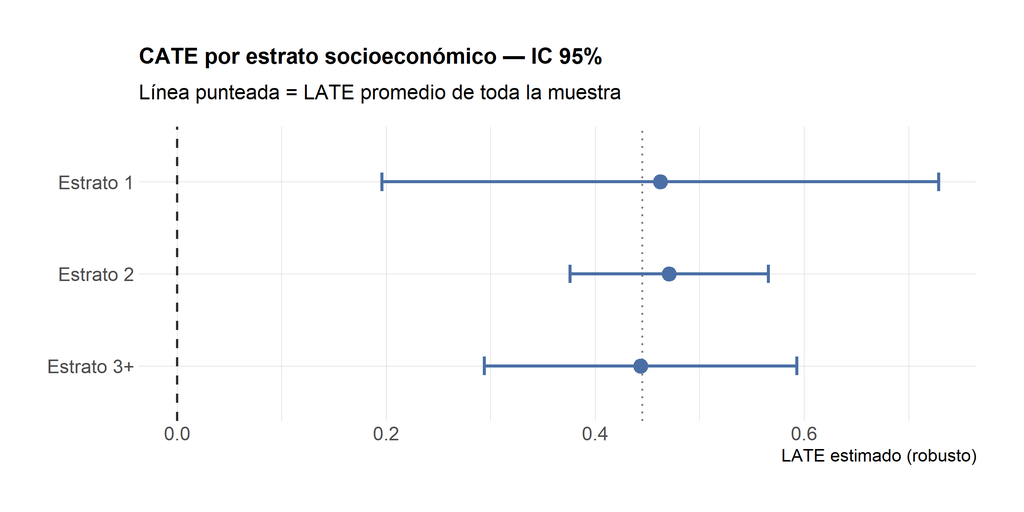

```r
cate_estrato %>%
  mutate(Subgrupo = fct_rev(fct_inorder(Subgrupo))) %>%
  ggplot(aes(x = LATE, y = Subgrupo)) +
  geom_vline(xintercept = 0,         color = COL_UMBR, linetype = "dashed", linewidth = 0.7) +
  geom_vline(xintercept = late_main, color = COL_UMBR, linetype = "dotted", linewidth = 0.6, alpha = 0.6) +
  geom_errorbarh(aes(xmin = `IC inf.`, xmax = `IC sup.`),
                 height = 0.2, linewidth = 0.9, color = COL_CTRL) +
  geom_point(size = 4, color = COL_CTRL) +
  labs(title = "CATE por estrato socioeconómico — IC 95%",
       subtitle = "Línea punteada = LATE promedio de toda la muestra",
       x = "LATE estimado (robusto)", y = NULL) +
  theme(legend.position = "none")
```

## 5. Interseccionalidad: género × URM

Exploramos si la heterogeneidad de género y étnica se amplifica o se modera cuando se cruzan ambas dimensiones.

```r
cate_int <- bind_rows(
  cate_run(df$icfes_female == 0 & df$icfes_urm == 0, "Hombre, No URM"),
  cate_run(df$icfes_female == 0 & df$icfes_urm == 1, "Hombre, URM"),
  cate_run(df$icfes_female == 1 & df$icfes_urm == 0, "Mujer, No URM"),
  cate_run(df$icfes_female == 1 & df$icfes_urm == 1, "Mujer, URM")
)

# Verificar precisión: SE > 0.10 indica submuestra demasiado pequeña para conclusiones firmes
cate_int_display <- cate_int %>%
  mutate(
    Advertencia = ifelse(SE > 0.10,
                         "⚠️ SE alto — muestra pequeña, resultado indicativo",
                         "✓")
  )

cate_int_display %>%
  kable(caption = "CATE por intersección género × URM (SE > 0.10 → resultado impreciso)") %>%
  kable_styling(bootstrap_options = c("striped", "hover", "condensed")) %>%
  column_spec(ncol(cate_int_display),
              bold = TRUE,
              color = ifelse(cate_int_display$SE > 0.10, COL_TRAT, COL_CTRL))
```

CATE por intersección género × URM (SE > 0.10 → resultado impreciso)

| Subgrupo | n | LATE | SE | p-valor | IC inf. | IC sup. | h | N ef. | Advertencia |
| --- | --- | --- | --- | --- | --- | --- | --- | --- | --- |
| Hombre, No URM | 12254 | 0.3846 | 0.0498 | 0.0000 | 0.2870 | 0.4821 | 12.35 | 5516 | ✓ |
| Hombre, URM | 898 | 0.4278 | 0.2180 | 0.0497 | 0.0006 | 0.8550 | 8.92 | 271 | ⚠️ SE alto — muestra pequeña, resultado indicativo |
| Mujer, No URM | 9321 | 0.5357 | 0.0646 | 0.0000 | 0.4091 | 0.6624 | 7.41 | 2613 | ✓ |
| Mujer, URM | 659 | 0.3377 | 0.3351 | 0.3135 | -0.3191 | 0.9945 | 6.34 | 146 | ⚠️ SE alto — muestra pequeña, resultado indicativo |

[figure not shown]

```r
cate_int %>%
  mutate(
    Género = ifelse(grepl("Mujer", Subgrupo), "Mujer", "Hombre"),
    URM    = ifelse(grepl("URM", Subgrupo), "Minoría (URM)", "No minoría"),
    Subgrupo = fct_rev(fct_inorder(Subgrupo))
  ) %>%
  ggplot(aes(x = LATE, y = Subgrupo, color = Género, shape = URM)) +
  geom_vline(xintercept = 0,         color = COL_UMBR, linetype = "dashed", linewidth = 0.7) +
  geom_vline(xintercept = late_main, color = COL_UMBR, linetype = "dotted", linewidth = 0.6, alpha = 0.6) +
  geom_errorbarh(aes(xmin = `IC inf.`, xmax = `IC sup.`),
                 height = 0.2, linewidth = 0.8) +
  geom_point(size = 4) +
  scale_color_manual(values = c("Hombre" = COL_CTRL, "Mujer" = COL_TRAT)) +
  scale_shape_manual(values = c("No minoría" = 16, "Minoría (URM)" = 17)) +
  labs(title = "CATE por intersección género × URM — IC 95%",
       subtitle = "Triángulo = minoría URM | Círculo = no minoría",
       x = "LATE estimado (robusto)", y = NULL,
       color = NULL, shape = NULL) +
  theme(legend.position = "top")
```

## 6. Forest plot general de heterogeneidad

Consolidamos todos los CATEs estimados en un solo gráfico comparativo.

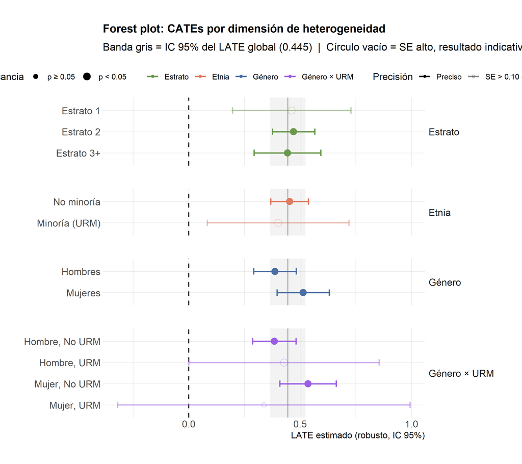

```r
all_cates <- bind_rows(
  cate_genero  %>% mutate(Dimensión = "Género"),
  cate_urm     %>% mutate(Dimensión = "Etnia"),
  cate_estrato %>% mutate(Dimensión = "Estrato"),
  cate_int     %>% mutate(Dimensión = "Género × URM")
) %>%
  mutate(
    Subgrupo  = fct_rev(fct_inorder(Subgrupo)),
    sig       = `p-valor` < 0.05,
    impreciso = SE > 0.10   # SE alto → submuestra pequeña → resultados indicativos
  )

# Línea del LATE global con IC para referencia
late_ci_l <- main_fit$ci[3, 1]
late_ci_u <- main_fit$ci[3, 2]

ggplot(all_cates, aes(x = LATE, y = Subgrupo, color = Dimensión)) +
  # LATE global como banda de referencia
  annotate("rect", xmin = late_ci_l, xmax = late_ci_u,
           ymin = -Inf, ymax = Inf, alpha = 0.06, fill = COL_UMBR) +
  geom_vline(xintercept = 0,         color = COL_UMBR, linetype = "dashed", linewidth = 0.7) +
  geom_vline(xintercept = late_main, color = COL_UMBR, linetype = "solid",  linewidth = 0.5, alpha = 0.5) +
  geom_errorbarh(aes(xmin = `IC inf.`, xmax = `IC sup.`, alpha = impreciso),
                 height = 0.3, linewidth = 0.8) +
  geom_point(aes(size = sig, alpha = impreciso, shape = impreciso)) +
  scale_color_manual(values = c(
    "Género"       = "#4A6FA5",
    "Etnia"        = "#E07A5F",
    "Estrato"      = "#6A994E",
    "Género × URM" = "#9B5DE5"
  )) +
  scale_size_manual(values = c("TRUE" = 4, "FALSE" = 2.5),
                    labels = c("TRUE" = "p < 0.05", "FALSE" = "p ≥ 0.05"),
                    name = "Significancia") +
  scale_alpha_manual(values = c("TRUE" = 0.45, "FALSE" = 1),
                     labels = c("TRUE" = "SE > 0.10 (impreciso)", "FALSE" = "Preciso"),
                     name = "Precisión") +
  scale_shape_manual(values = c("TRUE" = 1, "FALSE" = 16),
                     labels = c("TRUE" = "SE > 0.10 (impreciso)", "FALSE" = "Preciso"),
                     name = "Precisión") +
  facet_grid(Dimensión ~ ., scales = "free_y", space = "free_y") +
  labs(
    title    = "Forest plot: CATEs por dimensión de heterogeneidad",
    subtitle = paste0("Banda gris = IC 95% del LATE global (", round(late_main, 3),
                      ")  |  Círculo vacío = SE alto, resultado indicativo"),
    x        = "LATE estimado (robusto, IC 95%)",
    y        = NULL,
    color    = NULL
  ) +
  theme(
    legend.position = "top",
    strip.text.y    = element_text(angle = 0, hjust = 0)
  )
```

## 7. Tabla resumen de todos los CATEs

```r
all_cates %>%
  select(Dimensión, Subgrupo, n, LATE, SE, `p-valor`, `IC inf.`, `IC sup.`, h) %>%
  arrange(Dimensión, Subgrupo) %>%
  kable(caption = "Resumen de CATEs por subgrupo — todas las dimensiones") %>%
  kable_styling(bootstrap_options = c("striped", "hover", "condensed"),
                font_size = 12) %>%
  pack_rows("Género",       1, 2) %>%
  pack_rows("Etnia (URM)",  3, 4) %>%
  pack_rows("Estrato",      5, 7) %>%
  pack_rows("Género × URM", 8, 11)
```

Resumen de CATEs por subgrupo — todas las dimensiones

[output not shown]

## 8. Caracterización de los compliers por subgrupo

¿Quiénes son los *compliers* en cada subgrupo? La proporción de compliers en un subgrupo X es proporcional a la **primera etapa local** dentro de ese subgrupo. Si el subgrupo X tiene una primera etapa más alta que el promedio, está sobre-representado entre los compliers.

```r
# Primera etapa global (dentro del ancho de banda h*)
df_bw  <- df %>% filter(abs(X1) <= h_main)
pi_global <- mean(df_bw$D[df_bw$T == 1], na.rm = TRUE) -
             mean(df_bw$D[df_bw$T == 0], na.rm = TRUE)

# Primera etapa por subgrupo dentro del ancho de banda
primera_etapa_sub <- function(mask_str, label) {
  mask   <- eval(parse(text = mask_str), envir = df_bw)
  sub_bw <- df_bw[!is.na(mask) & mask, ]
  pi_sub <- mean(sub_bw$D[sub_bw$T == 1], na.rm = TRUE) -
            mean(sub_bw$D[sub_bw$T == 0], na.rm = TRUE)
  p_sub  <- mean(!is.na(mask) & mask)   # fracción de la muestra BW
  tibble(
    Subgrupo          = label,
    `% en muestra BW` = round(p_sub * 100, 1),
    `π subgrupo`      = round(pi_sub, 4),
    `π global`        = round(pi_global, 4),
    `Índice relativo` = round(pi_sub / pi_global, 3)
  )
}

complier_tbl <- bind_rows(
  primera_etapa_sub("icfes_female == 1", "Mujeres"),
  primera_etapa_sub("icfes_female == 0", "Hombres"),
  primera_etapa_sub("icfes_urm == 1",    "Minoría URM"),
  primera_etapa_sub("icfes_urm == 0",    "No minoría"),
  primera_etapa_sub("!is.na(icfes_stratum) & icfes_stratum == 1", "Estrato 1"),
  primera_etapa_sub("!is.na(icfes_stratum) & icfes_stratum == 2", "Estrato 2"),
  primera_etapa_sub("!is.na(icfes_stratum) & icfes_stratum >= 3", "Estrato 3+")
)

complier_tbl %>%
  kable(caption = paste0(
    "Caracterización de compliers por subgrupo (dentro de h* = ",
    round(h_main, 2), ")"
  )) %>%
  kable_styling(bootstrap_options = c("striped", "hover", "condensed"),
                full_width = FALSE) %>%
  column_spec(5, bold = TRUE,
              color = ifelse(complier_tbl$`Índice relativo` > 1,
                             COL_TRAT, COL_CTRL))
```

Caracterización de compliers por subgrupo (dentro de h* = 9.04)

| Subgrupo | % en muestra BW | π subgrupo | π global | Índice relativo |
| --- | --- | --- | --- | --- |
| Mujeres | 43.3 | 0.6419 | 0.619 | 1.037 |
| Hombres | 56.7 | 0.6012 | 0.619 | 0.971 |
| Minoría URM | 6.0 | 0.6426 | 0.619 | 1.038 |
| No minoría | 94.0 | 0.6173 | 0.619 | 0.997 |
| Estrato 1 | 14.3 | 0.5783 | 0.619 | 0.934 |
| Estrato 2 | 50.9 | 0.6284 | 0.619 | 1.015 |
| Estrato 3+ | 34.6 | 0.6265 | 0.619 | 1.012 |

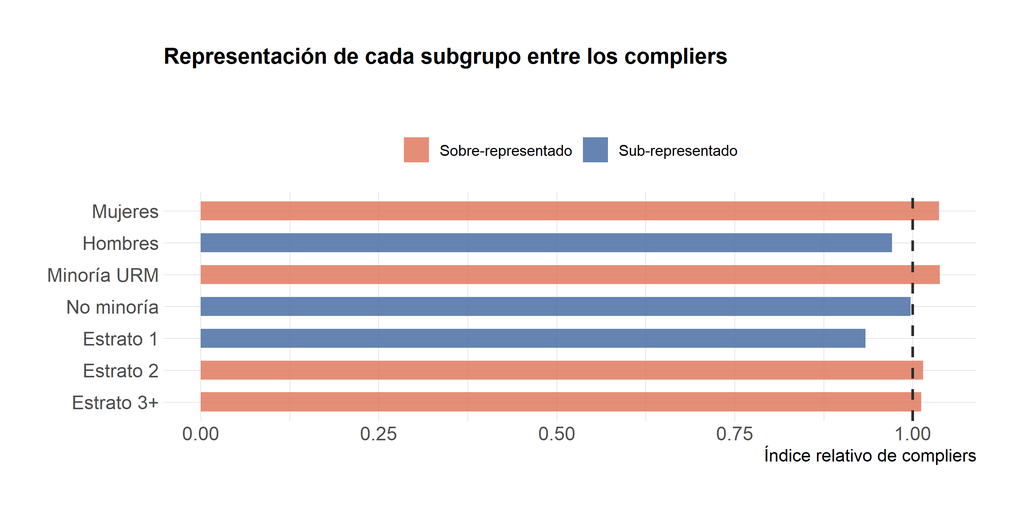

```r
complier_tbl %>%
  mutate(
    Subgrupo = fct_rev(fct_inorder(Subgrupo)),
    color    = ifelse(`Índice relativo` > 1, "Sobre-representado", "Sub-representado")
  ) %>%
  ggplot(aes(x = `Índice relativo`, y = Subgrupo, fill = color)) +
  geom_col(width = 0.6, alpha = 0.85) +
  geom_vline(xintercept = 1, color = COL_UMBR, linewidth = 0.8, linetype = "dashed") +
  scale_fill_manual(values = c("Sobre-representado" = COL_TRAT,
                                "Sub-representado"  = COL_CTRL)) +
  labs(
    title    = "Representación de cada subgrupo entre los compliers",
    subtitle = "Índice = π(subgrupo) / π(global)  |  > 1 → sobre-representado entre compliers",
    x        = "Índice relativo de compliers",
    y        = NULL,
    fill     = NULL
  ) +
  theme(legend.position = "top")
```

> **Lectura:** Un índice > 1 indica que ese subgrupo responde más al umbral (proporcionalmente más compliers). Esto no implica un efecto mayor — eso lo miden los CATEs. El índice mide la *densidad* de compliers, que determina qué población está siendo identificada en cada CATE.

## 9. Implicaciones para validez externa

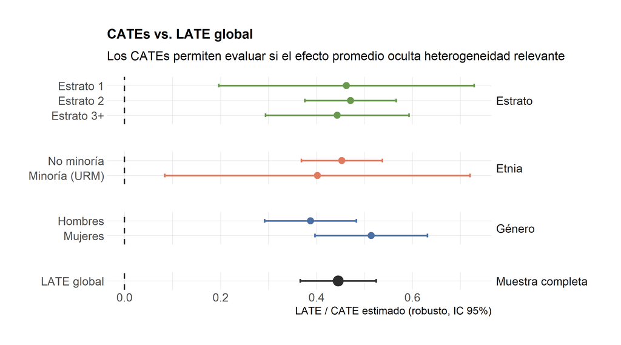

```r
# Comparamos el LATE global con los CATEs para evaluar sesgos de agregación
cate_summary <- all_cates %>%
  filter(Dimensión != "Género × URM") %>%
  select(Dimensión, Subgrupo, LATE, `IC inf.`, `IC sup.`, n) %>%
  bind_rows(
    tibble(Dimensión = "Muestra completa",
           Subgrupo  = "LATE global",
           LATE      = late_main,
           `IC inf.` = main_fit$ci[3,1],
           `IC sup.` = main_fit$ci[3,2],
           n         = nrow(df))
  ) %>%
  mutate(Subgrupo = fct_rev(fct_inorder(Subgrupo)))

ggplot(cate_summary, aes(x = LATE, y = Subgrupo,
                         color = Dimensión, size = Dimensión == "Muestra completa")) +
  geom_vline(xintercept = 0, color = COL_UMBR, linetype = "dashed", linewidth = 0.7) +
  geom_errorbarh(aes(xmin = `IC inf.`, xmax = `IC sup.`),
                 height = 0.25, linewidth = 0.8) +
  geom_point() +
  scale_color_manual(values = c(
    "Muestra completa" = COL_UMBR,
    "Género"     = "#4A6FA5",
    "Etnia"      = "#E07A5F",
    "Estrato"    = "#6A994E"
  )) +
  scale_size_manual(values = c("TRUE" = 5, "FALSE" = 3), guide = "none") +
  facet_grid(Dimensión ~ ., scales = "free_y", space = "free_y") +
  labs(
    title    = "CATEs vs. LATE global",
    subtitle = "Los CATEs permiten evaluar si el efecto promedio oculta heterogeneidad relevante",
    x        = "LATE / CATE estimado (robusto, IC 95%)",
    y        = NULL, color    = NULL
  ) +
  theme(
    legend.position = "none",
    strip.text.y    = element_text(angle = 0, hjust = 0)
  )
```

## Resumen de hallazgos de heterogeneidad

```r
# Armamos el resumen con datos calculados
genero_diff <- test_diff(
  cate_genero$LATE[cate_genero$Subgrupo == "Mujeres"],
  cate_genero$SE[cate_genero$Subgrupo   == "Mujeres"],
  cate_genero$LATE[cate_genero$Subgrupo == "Hombres"],
  cate_genero$SE[cate_genero$Subgrupo   == "Hombres"],
  "Mujeres vs. Hombres"
)
urm_diff <- test_diff(
  cate_urm$LATE[cate_urm$Subgrupo == "Minoría (URM)"],
  cate_urm$SE[cate_urm$Subgrupo   == "Minoría (URM)"],
  cate_urm$LATE[cate_urm$Subgrupo == "No minoría"],
  cate_urm$SE[cate_urm$Subgrupo   == "No minoría"],
  "URM vs. No URM"
)

tibble(
  Dimensión = c("LATE global", "Género", "Etnia (URM)", "Estrato"),
  `Valores (LATE robusto)` = c(
    paste0(round(late_main, 3),
           "  SE = ", round(se_main, 3)),
    paste0("Mujeres = ", cate_genero$LATE[cate_genero$Subgrupo == "Mujeres"],
           "  |  Hombres = ", cate_genero$LATE[cate_genero$Subgrupo == "Hombres"]),
    paste0("URM = ",  cate_urm$LATE[cate_urm$Subgrupo == "Minoría (URM)"],
           "  |  No URM = ", cate_urm$LATE[cate_urm$Subgrupo == "No minoría"]),
    paste0("E1 = ", cate_estrato$LATE[cate_estrato$Subgrupo == "Estrato 1"],
           "  |  E2 = ", cate_estrato$LATE[cate_estrato$Subgrupo == "Estrato 2"],
           "  |  E3+ = ", cate_estrato$LATE[cate_estrato$Subgrupo == "Estrato 3+"])
  ),
  `Test diferencia` = c(
    "—",
    paste0("z = ", genero_diff$`z-stat`, "  p = ", genero_diff$`p-valor`,
           "  ", genero_diff$Sig.),
    paste0("z = ", urm_diff$`z-stat`,    "  p = ", urm_diff$`p-valor`,
           "  ", urm_diff$Sig.),
    "Ver tabla §4"
  )
) %>%
  kable(caption = "Resumen de heterogeneidad del efecto SPP") %>%
  kable_styling(bootstrap_options = c("striped", "hover"), full_width = TRUE) %>%
  column_spec(1, bold = TRUE, width = "15%") %>%
  column_spec(2, width = "50%") %>%
  column_spec(3, width = "35%")
```

Resumen de heterogeneidad del efecto SPP

| Dimensión | Valores (LATE robusto) | Test diferencia |
| --- | --- | --- |
| LATE global | 0.445 SE = 0.04 | — |
| Género | Mujeres = 0.5142 &#124; Hombres = 0.3876 | z = 1.64 p = 0.101 n.s. |
| Etnia (URM) | URM = 0.402 &#124; No URM = 0.4529 | z = -0.303 p = 0.7618 n.s. |
| Estrato | E1 = 0.4624 &#124; E2 = 0.4709 &#124; E3+ = 0.4435 | Ver tabla §4 |

**Siguientes pasos — `05_sensibilidad.Rmd`:**

1. **E-values** (Ding & VanderWeele): ¿qué tan fuerte tendría que ser un confusor no observado para anular el LATE?
2. **Estratificación principal**: análisis del sesgo de selección post-tratamiento en Y (el resultado solo se observa para quienes completan)
3. Discusión integrada para el reporte final